# A carriage-road path from downtown Camden to the Snow Bowl: who gains, who gives, who pays?

Cory Whitney

05 October 2026

**Where I am coming from.** I am a Camden resident. I run a non-profit and an LLC in town, and my home is just off Hosmer Pond Road, on Emery Way, on the way to the Snow Bowl. My neighbors and I have talked about this, and we think a separated path would be a great thing: cycling on the road as it is today is too dangerous, and a safe route could bring major benefits to the town. That is my view and I want you to know it up front. I may also be one of the neighbors a path would pass, so I have a personal stake. The analysis below tries to give every group’s view equal space, including the ones that would lose something, and its numbers are placeholders, not support for my opinion.

**Draft for discussion.** This is a thinking tool, not a recommendation. The route facts below come from public map data. The dollar and benefit figures behind the charts are **placeholders** I made up so the model runs; none has been measured or agreed with anyone yet. The point of publishing now is to ask the right people for the real numbers.

## The question

Should Camden build a separated carriage-road path between downtown and the Camden Snow Bowl, instead of relying on Hosmer Pond Road as it is today? People look at the same stretch of ground and see very different things: a safer ride, a quiet home, a working forest, a ski hill that needs visitors, a tax bill. This project writes each of those views down on its own terms, then lines them up side by side.

## What the map says

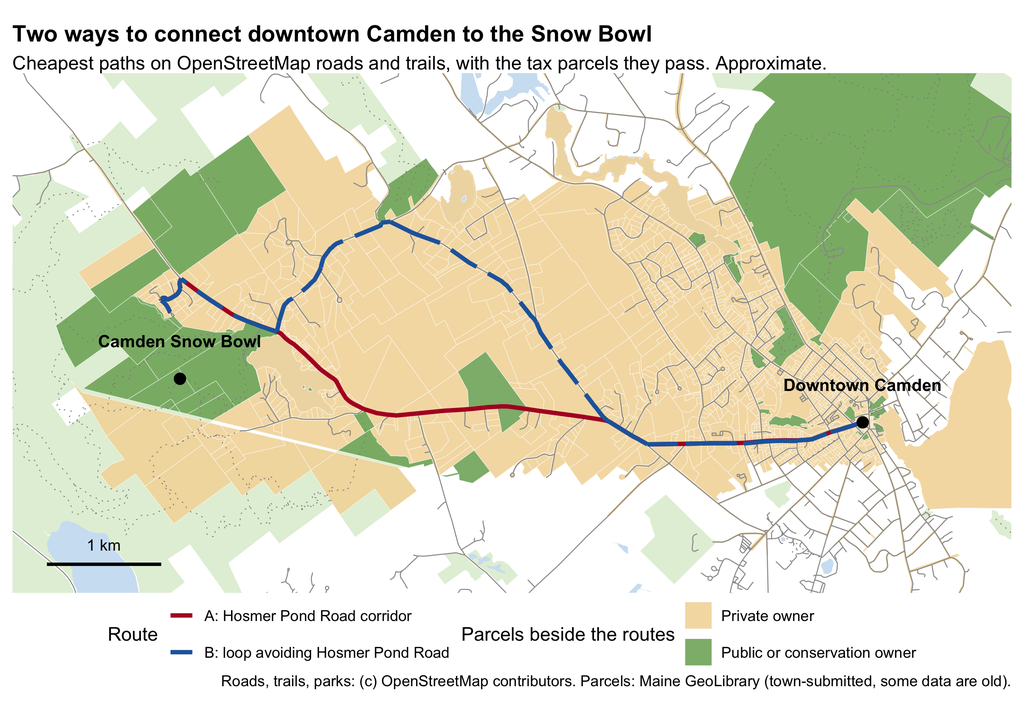

- The most direct connection follows **Mechanic Street, Hosmer Pond Road and Barnestown Road**: 6.91 km on the map, against 5.98 km in a straight line.
- The best alternative that avoids Hosmer Pond Road is a northern loop of 7.87 km, about 14% longer.
- A path beside the main route would pass about **206 tax parcels** (197 privately owned, 9 public or conservation land). That is a lot of neighbors to talk to, whichever design is chosen.
- The climb from downtown to the road base is about **127 m** over the route (189 m of total ascent; steepest 100 m stretch about 15.4%).

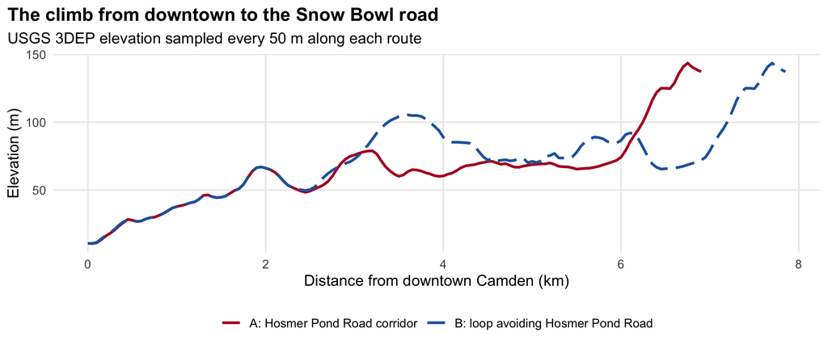

## The Snow Bowl is the Town

The Snow Bowl is owned by the Town and run by Parks and Recreation. In the Town’s FY2026 budget message it is listed among the “special revenue funds”, separate from the General Fund, and the manager writes that it “remains difficult for the Snow Bowl to turn a profit.” So a path is not a deal between the Town and some outside business. It is **one budget with two pockets**:

- the **General Fund** (taxes), which would carry most of the construction and upkeep, and
- the **Snow Bowl fund**, which would earn more from added visitors, for example from mountain-biking and bikepacking visitors (a possible growth area), but also carries more liability.

A natural design is to **earmark the Snow Bowl’s added margin** to the path, and ask the model whether that is enough.

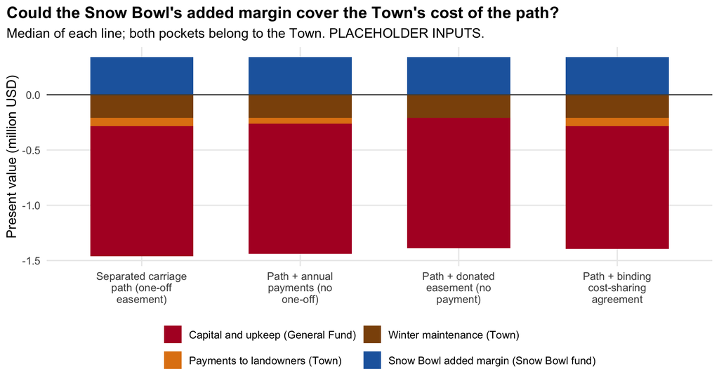

## Who sees what

Eleven groups started as separate voices; with the Snow Bowl folded into the Town there are ten: hosting landowners, neighbors, forest managers, the ecosystem, cyclists, hikers, drivers, the Town, tourism and business, and climate and future residents. Each gets its own cause-and-effect diagram and its own measures of a good outcome. Blue below means a group gains, red means a loss. Bigger bubbles are bigger effects on that group’s own scale; fainter bubbles mean we are less sure of the direction.

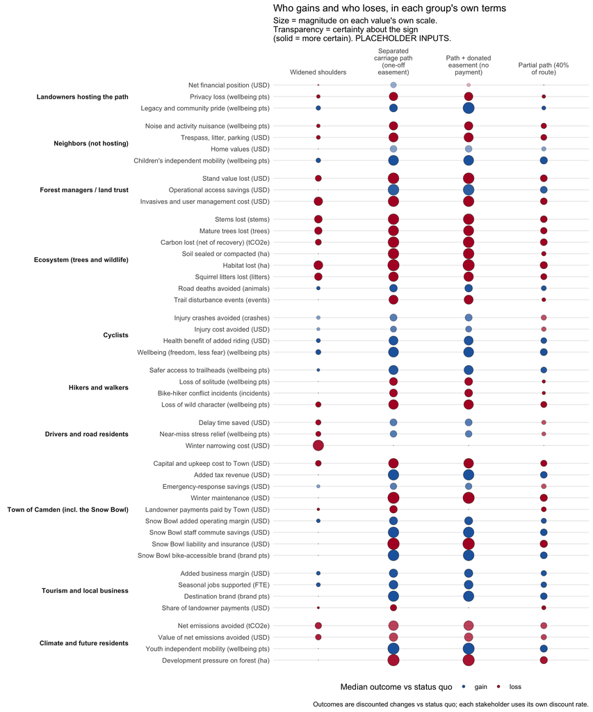

**No option is free of losers.** With these placeholder numbers, a path helps cyclists, drivers and business and costs the forest and ecosystem groups, so choosing is partly choosing who bears the cost. The model keeps the groups separate on purpose, and does not add them into one score.

## Who gives and who pays

Landowners would host a path on their land. The model tests four ways of dealing with them: refuse, a one-time payment, yearly payments, or a **donated easement**. Two practical issues matter:

- **Payment level.** A fair one-time price is usually found by comparing the land’s value before and after the easement (an appraisal); Maine’s constitution requires just compensation when private property is taken for public use.
- **Liability.** Maine’s recreational use law (14 MRSA 159-A) limits an owner’s duty of care to people using land for recreation, but not where permission is given **for payment**. Whether paying for an easement loses that protection is a question for a Maine attorney, so the model runs both cases.

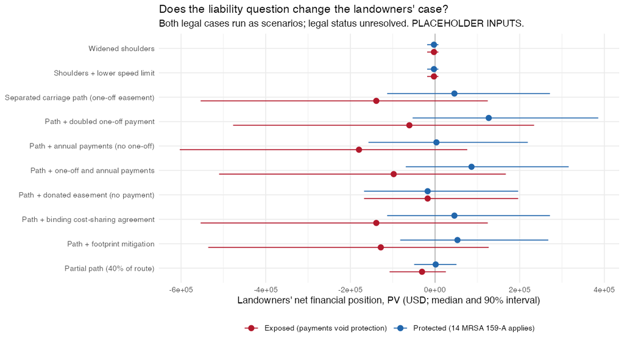

## Will it happen on its own?

A second step treats the Town (with the Snow Bowl), landowners and local business as players who each choose what to do. We ask which outcomes are stable, meaning nobody would change their own choice.

With the placeholder numbers, **a path is a stable outcome in about 62% of the simulated worlds, and doing nothing is stable in about 46%**. Both can hold at once, which is a coordination problem: everyone could be better off, but only if it all happens together. The most promising version is the one where landowners **donate** easements, because nobody has to pay them (the tax treatment needs a tax advisor).

In an earlier version of this model the Snow Bowl was a separate player, and the Town looked like the blocker. Counting the Snow Bowl’s gains inside the Town’s own books changed that. It is a good example of why it matters how we draw the boundaries.

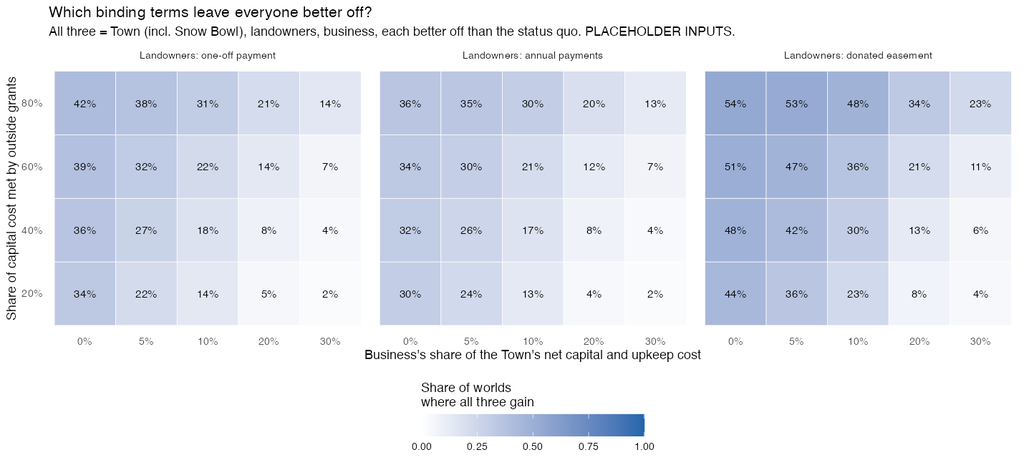

## What we need from you

1. **Real numbers:** what do trips, injuries, upkeep and visitor spending look like today?
2. **Landowner views:** what would make hosting acceptable: a payment, a donation, a liability guarantee?
3. **The Snow Bowl’s books:** how much of a path’s added margin could be earmarked?
4. **Anyone missing:** which voices should be added (state park, fire and EMS, school)?

The model, data and code are open: see the [repository](https://github.com/CWWhitney/camden_carriage_road) and the longer technical vignette. Comments and corrections are welcome.

Map data: (c) OpenStreetMap contributors. Parcels: Maine GeoLibrary (town-submitted; some data are old). Elevation: USGS 3DEP. Budget facts: Town of Camden FY2026 municipal budget message. All benefit and cost inputs in the charts are placeholders.